# Exploring Age and Sex Dynamics in Juvenile Violence Trends

Nathan Rethwisch

2024-05-07

The purpose of this document is to analyze how sex and age affect the proportion of juvenile offenders that were detained in a juvenile facility for violent crimes as opposed to nonviolent crimes. The document highlights where the data comes from, the procedure and results used to model the effect of sex and age on violence, and an overall discussion of the conclusions drawn from these results.

## Introduction

Understanding trends among juvenile violence is important for assessing risk factors, creating new policy, and advocating for reform within the juvenile legal system. Therefore, in this study, we will take a further look at how age and sex are related to the proportion of juveniles in detention facilities that have committed violent crimes.

This data comes from the Iowa government and highlights all juvenile delinquency placements from July 2003 through October 2020. The dataset includes information on the child’s age when admitted, type of charge they were admitted on, the sex and race of the child, the facility they were kept at, the month and year of their release, and the number of days they were held. In total, there were 60599 juvenile placement records in this database.

More information on the dataset can be found at the [Iowa Data website.](https://data.iowa.gov/Juvenile-Detention/Iowa-Juvenile-Detention-Secure-Placements/3kck-gq3y/about_data)

## Data

For this analysis, we want to focus on the proportion of crimes that were considered violent among those placed in a juvenile detention center. [According to Iowa Legislature](https://www.legis.iowa.gov/docs/code/915.10.pdf), a violent crime includes “a forcible felony, or any felony or aggravated misdemeanor which involved the actual or threatened infliction of physical or emotional injury on one or more persons.” In this dataset, 22720 of the 60599 juveniles were detained for violent crimes, meaning that 37.49% of juveniles in detention centers are there for violent crimes. These mainly included arson, assault, kidnapping, murder, burglary/theft, and sex crimes. The table below gives a breakdown of violent crimes by what type of crime was committed:

| Charge Subtype | Count (Proportion) |
| --- | --- |
| Assault | 17140 (75.4%) |
| Burglary/Robbery | 2383 (10.5%) |
| Sex | 2246 (9.9%) |
| Other | 390 (1.7%) |
| Arson | 275 (1.2%) |
| Murder/Manslaughter | 186 (0.8%) |
| Kidnapping | 100 (0.4%) |
| Total | 22720 |

Furthermore, there were more males that were in juvenile detention centers in this dataset, with 48301 males and only 12298 females. The following table breaks down the number and proportion of violent crimes by gender:

| Sex | Total Offenders | Violent Offenders | Proportion Who are Violent Offenders |
| --- | --- | --- | --- |
| FEMALE | 12298 (20.29%) | 5061 | 0.41 |
| MALE | 48301 (79.71%) | 17659 | 0.37 |

Although there are far more males in the dataset, with 79.71% of detained juveniles in Iowa being male, females were actually more likely to be detained on violent crimes, with 41% of female juveniles committing violent crimes and 37% of male juveniles committing violent crimes.

| Admission Age | Total Offenders | Violent Offenders | Proportion Who are Violent Offenders |
| --- | --- | --- | --- |
| 9 | 7 (0.01%) | 7 | 1.00 |
| 10 | 57 (0.09%) | 39 | 0.68 |
| 11 | 316 (0.52%) | 207 | 0.66 |
| 12 | 1469 (2.42%) | 856 | 0.58 |
| 13 | 4159 (6.86%) | 2046 | 0.49 |
| 14 | 8126 (13.41%) | 3442 | 0.42 |
| 15 | 12575 (20.75%) | 4756 | 0.38 |
| 16 | 16372 (27.02%) | 5776 | 0.35 |
| 17 | 17470 (28.83%) | 5574 | 0.32 |
| 18 | 46 (0.08%) | 16 | 0.35 |
| 19 | 2 (0%) | 1 | 0.50 |

Note that 18 and 19 year olds can be selected for juvenile detention if they are deemed “mentally immature,” so this explains the few offenders in these age ranges. Interestingly, there seems to be a linear relationship between age and the proportion of juveniles who are violent offenders, with 100% of 9-year olds being sentenced for violent crimes, and decreasing proportions as the ages increase. This decrease intuitively makes sense because younger children are likely to be given lesser punishments as long as the crimes are nonviolent. The proportion slightly increases for 18 and 19 year-olds, but there are few total offenders due to most people this age being sentenced to adult detention centers.

The figure below displays a scatterplot, with the proportion of violent crimes on the y-axis, and the age when admitted to the juvenile detention facility on the x-axis. Furthermore, the sex of the child is denoted by both the color and symbol. There were no female offenders in the dataset that were age 9 or 19, so this is why there are no points on the graph for those ages.

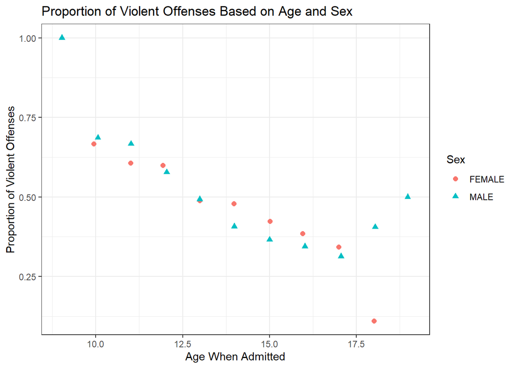

## Results

Because we are trying to model the probability of something occurring, a logistic regression model is appropriate in this scenario. In this case, the response variable is the probability of a child in juvenile detention being there for a violent crime. The explanatory variables are sex and age when admitted. An interaction term between admission age and sex was considered, but was not included in the final model, because it was not found to be significant from a Wald test (P-value of 0.78).

The binomial model looks like this:
$$\hat{p} = \frac{e^{B_0 + B_1X_1 +
B_2X_2}}{1+e^{B_0 + B_1X_1 + B_2X_2}}$$
where

- $\hat{p}$ is the predicted probability of the juvenile
- $B_0$ is the intercept
- $B_1$ is the coefficient associated with Sex
- $X_1$ is whether the observed juvenile is male (1) or female (0)
- $B_2$ is the coefficient associated with Age
- $X_2$ is the age of the observed juvenile

After fitting our data, we get a model that looks like this:
$$\hat{p} = \frac{e^{2.4186798 + -0.172978 * X_1 +
-0.1808698 * X_2}}{1 + e^{2.4186798 + -0.172978 * X_1 + -0.1808698 *
X_2}}$$
.

After performing a Wald test on the model, we find that both sex and admission age are significant predictors for the proportion of violent offenders, given the other predictors in the model. From this, we can obtain a 95% confidence interval to see what impact sex and age may have on the proportion of offenders in juvenile detention that have committed a violent crime.

A 95% confidence interval for the sex being female is (1.141, 1.238). This means that we are 95% confident that the odds of a female being a violent offender given they are in juvenile detention are between 1.141 and 1.238 times the odds of a male being a violent offender.

The following plot shows the model’s prediction for the proportion of children in juvenile detention that are there for a violent crime based on levels of admission age and sex as a line, with an associated 95% confidence interval. Because there are so many observations in this data, we have chosen to have the plotted points represent average proportions among the unique combinations of age and sex.

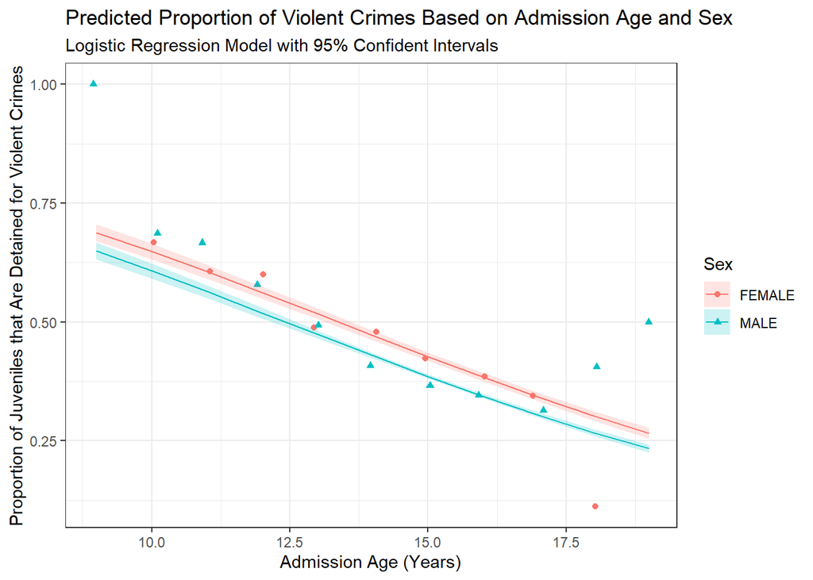

From this plot, we can tell that females are predicted to have a slightly higher proportion of being detained for violent crimes and age is related to a decrease in the proportion of being admitted for violent crimes.

All of this information leads to the conclusion that males have a lower proportion of children in juvenile detention for violent crimes than females. Furthermore, as age increases, the proportion of children in juvenile detention for violent crimes decrease. It is important to note that a decreased proportion does not equate to a decrease in the overall count of children in juvenile detention for violent crimes, as older males have a higher number of violent crimes, but a lower proportion.

## Discussion

This analysis was to ascertain the effect of sex and age on the proportion of juveniles that were sent to a detention facility for violent crimes. The data used for this analysis was all juvenile detention admissions in the state of Iowa from July 2003 through October 2020, taken from [Iowa’s government website](https://data.iowa.gov/Juvenile-Detention/Iowa-Juvenile-Detention-Secure-Placements/3kck-gq3y/about_data). After fitting a logistic regression model, we found that females have a higher proportion of violent admissions than males and that the proportion of admitted children who committed violent crimes decreases with age.

Some of the assumptions of using a logistic regression model were challenged in this analysis. One assumption is that observations have a binomial distribution, each with its own mean. The graph in the *Results* sections proves this assumption. It shows that the expected proportions from a binomial distribution are close to the actual proportions of violent offenders. Thus, this assumption is satisfied. However, observations violate the assumption of independence. Children can be double-counted in the admission data if they are transferred to multiple different juvenile detention facilities. This means that juveniles that committed violent crimes may be over-represented because violent offenders are likely to be in the detention system for longer thus having a better chance of being moved around. Another assumption of logistic regression is that the relationship between the probability of success (in this case the probability of a offender being violent) and explanatory variables is through the logit function. One way to show this relation is linear to so prove that interaction terms are not useful in this model. As previously stated, a Wald test reported a p-value of 0.78, meaning that the relationship is truly linear and this assumption is met.

There are some further limitations to the study, however. First, data is less widely available for the tail end of juvenile age, so claims about extremely young or old offenders are limited. Second, there were some manual entry errors noted in the data for things like years, and it can be assumed that there were some manual entry errors for variables of interest. However, because of the mass quantity of the data it is unlikely that these few errors would have a major impact on the conclusions in this report. Finally, we note that this data can only be applied to juveniles in Iowa, as this is where the data comes from. Therefore, the conclusion from this report is that among children in Iowa housed at juvenile detention facilities, the proportion that committed violent crimes is higher among females and decreases as a child grows older.